# Popularity Prediction

Vidwath R Hebse

11-Feb-2017

# Data Set Description

- Bar plot respresents a table of popularity against other predictor variables on train data, to visualize counts.

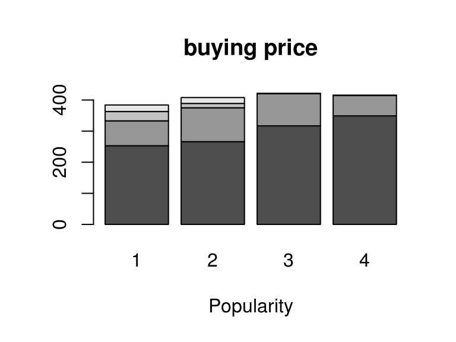

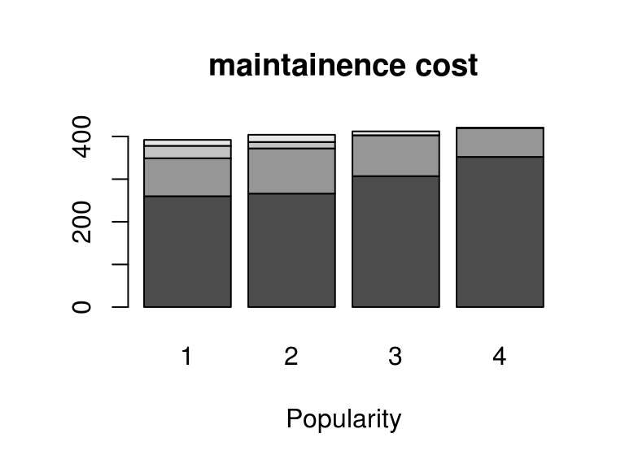

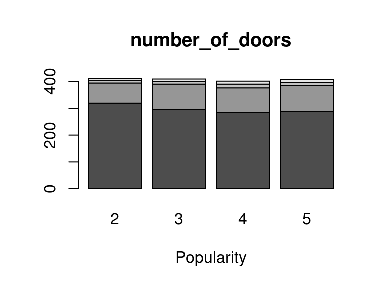

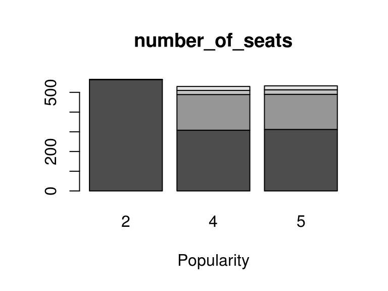

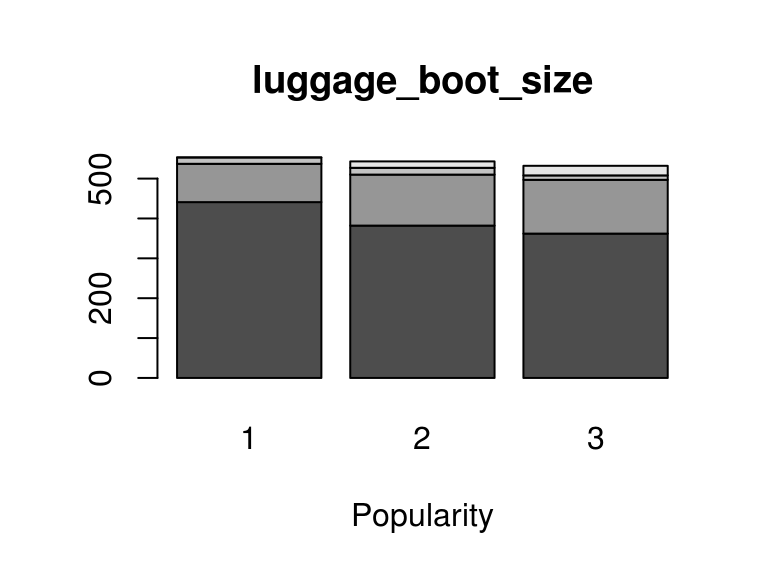

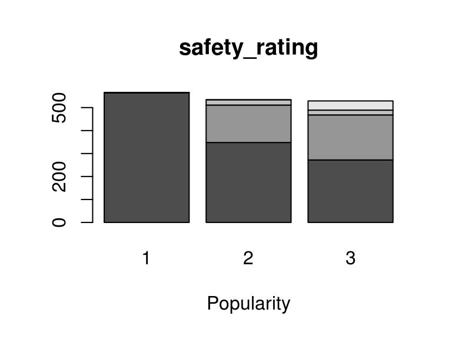

## Summary

### Data set quality

- Train and Test data is clean.
- No NA or missing values in the data set.
- As per the column description it had the given key values per column.
- No outliers found in the data.
- Response variable being “Popularity” and rest variables are predictors.

### Data Prepration

- Data was supposed to be processed based on its application.
- For multinomial regression (using nnet) and random forest, data was supposed to be made as factors.
- For XGboost all the data columns should be kept as numeric.

# Request Note

- Keeping every thing in mind, I still was unable to get 1000 result. It would be helpful for me If i get to know where I went wrong, so that I can correct my approach.
- Thanks and Regards
  - Vidwath R Hebse
  - vidwathrhebse@gmail.com
  - 9482204411